# Repeatability

Libby King

Last updated: 2017-03-07

## Intraclass correlation coefficient

First, plot the two measurements for head height (HeadHt) in the G44_Morphometrics.xlsx dataset against one another.

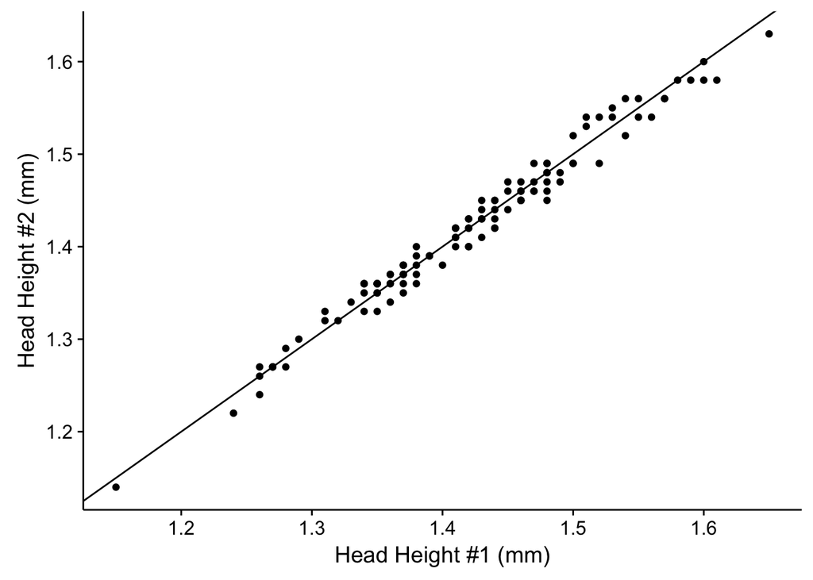

Based on your plot, do you expect repeatability to be high or low?

Now, follow the example from lecture to calculate repeatability of the head height (HeadHt) measurement using `anova(lm())`.

```r
Heads <- data.frame(HeadHt = c(M$HeadHt1, M$HeadHt2),
                      MouseID = factor(c(M$MouseID, M$MouseID)))
Heads <- Heads %>% drop_na()
fm <- aov(HeadHt ~ MouseID, data = Heads)
print(S <- summary(fm), digits = 5)
```

```
##              Df  Sum Sq  Mean Sq F value    Pr(>F)
## MouseID     116 1.85142 0.015960  175.34 < 2.2e-16
## Residuals   117 0.01065 0.000091
```

```r
var_a <- (S[[1]]$'Mean Sq'[1] - S[[1]]$'Mean Sq'[2]) / 2
var_a / (var_a + S[[1]]$'Mean Sq'[2])
```

```
## [1] 0.9886583
```

Now, calculate repeatability of the head height (HeadHt) measurement using `lme()` with MouseID treated as a random effect.

1. Fit a linear model using `lme()` with MouseID treated as a random effect.

```r
library(nlme)
fm_lme <- lme(HeadHt ~ 1,
              random = ~ 1 | MouseID,
              data = Heads,
              method = "ML")
```

2. Extract the coefficients of your model. Compare these with the means for each MouseID. Hint: `group_by()` and `summarize()` will help here. What is the relationship between the intercept estimates and the means calculated for each MouseID??

```r
head(coef(fm_lme))
```

```
##       (Intercept)
## 46001    1.593991
## 46002    1.454796
## 46003    1.375257
## 46004    1.390170
## 46012    1.350400
## 46013    1.365314
```

```r
MouseMeans <- Heads %>% group_by(MouseID) %>% summarize(mean(HeadHt))
```

3. Use `VarCorr()` to calculate the variace components for your model object. The first column of the output hold the two estimated variance components. No need to do further calculations. These are true variances, not mean squares. Use these to calculate repeatability. Also, use `var()` to get the variance of the means per MouseID you calculated in #2. What is the relationship between the variance of the means per MouseID and the variances from `VarCorr()`?

```r
(varcomps <- VarCorr(fm_lme))
```

```
## MouseID = pdLogChol(1)
##             Variance     StdDev
## (Intercept) 7.866515e-03 0.088693374
## Residual    9.102569e-05 0.009540738
```

```r
var.among <- as.numeric(varcomps[1, 1])
var.within <- as.numeric(varcomps[2, 1])
var.among / (var.among + var.within)
```

```
## [1] 0.9885611
```

```r
print(var(MouseMeans[,2]),digits=4)
```

```
##              mean(HeadHt)
## mean(HeadHt)      0.00798
```

```r
print(var.among, digits=4)
```

```
## [1] 0.007867
```

```r
MouseVars <- Heads %>% group_by(MouseID) %>% summarize(var(HeadHt))
MouseVars<-as.data.frame(MouseVars)

print(mean(as.numeric(MouseVars[,2])),digits=4)
```

```
## [1] 9.103e-05
```

```r
print(var.within, digits=4)
```

```
## [1] 9.103e-05
```